# twd5

Hubert Baniecki

17 listopada 2018

## Wtęp

W ramach 5 pracy domowej przeprowadziłem eksperyment porównania prezentacji danych w formie PieChart i BoxPlot. Dane o zadowoleniu ludzi w poszczególnych krajach świata w 2015 roku pochodziły z [Kaggle](https://www.kaggle.com/unsdsn/world-happiness). **Dane te idealnie pasowały do stworzenia mało czytelnego wykresu kołowego oraz bardzo treściwego wykresu BoxPlot. Chciałem sprawdzić jak ten drugi pomaga nam odczytać więcej różnych przydatnych informacji.** Stworzyłem dwa następujące wykresy, a następnie zadałem ankietowanym po 3 pytania do każdego z nich.

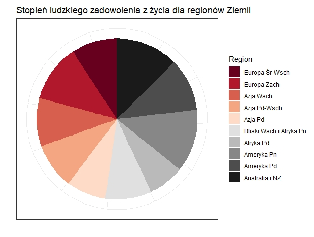

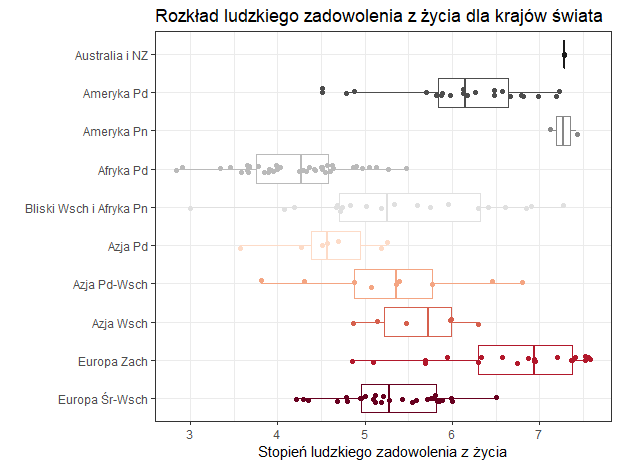

## Wyniki eksperymentu

### 1. Który region świata jest najszczęśliwszy?

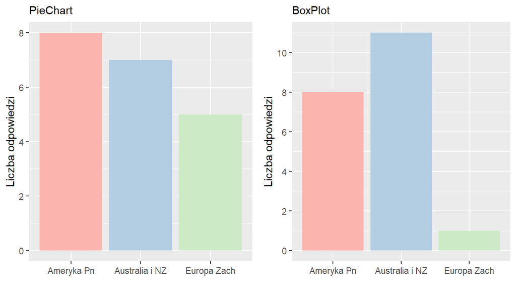

### 2. Który kolor zwrócił Twoją uwagę jako pierwszy?

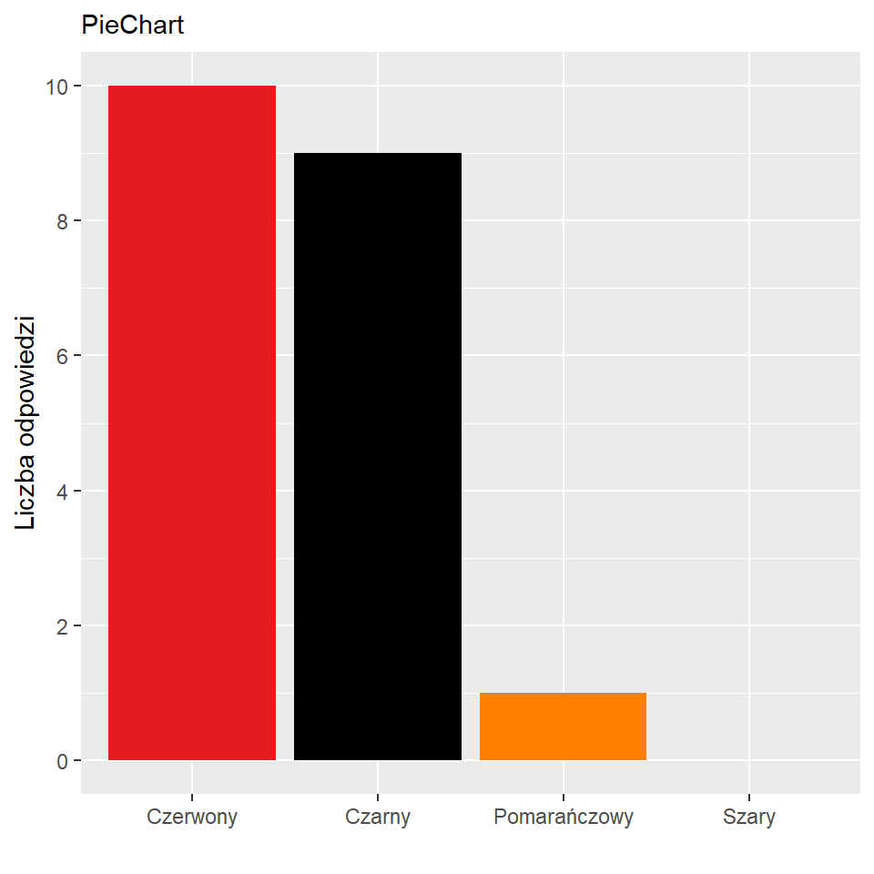

Przy pierwszym wykresie interesowało mnie na jakie kolory zwracamy szczególną uwagę przy oglądaniu wykresów. Wyniki mówią same za siebie. Będą to głownie wyraziste, wyróżniające się kontrastem kolory.

### 3. Czy 2 najciemniejsze kolory miały większą powierzchnie od 2 najjaśniejszych?

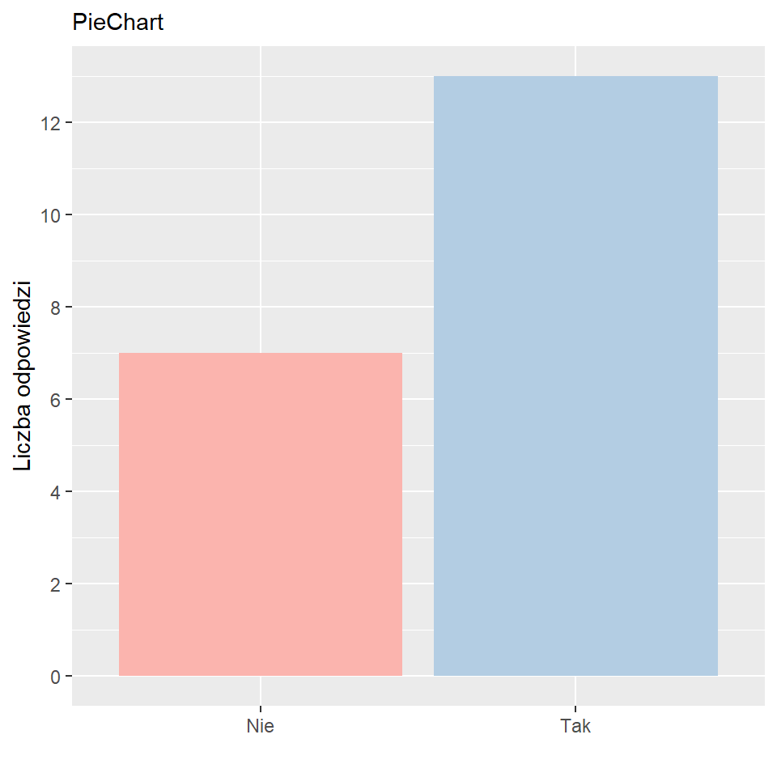

Zdziwiło mnie, że aż 1/3 ankietowanych miała problem ze wskazaniem poprawnej odpowiedzi w tym pytaniu. Niestety ciężko jest nam porównywać kąty na wykresie kołowym.

### 4. Który region miał najwięcej krajów?

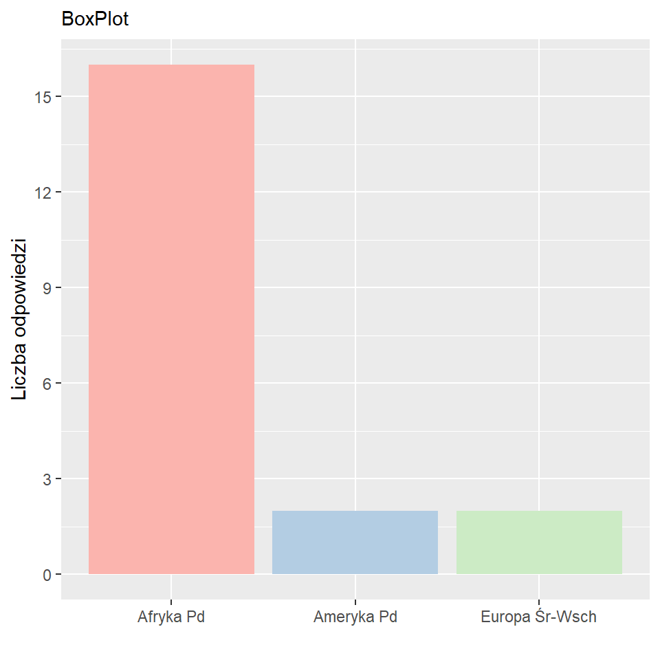

### 5. Który region miał największą różnicę pomiędzy najbardziej i najmniej zadowolonym krajem?

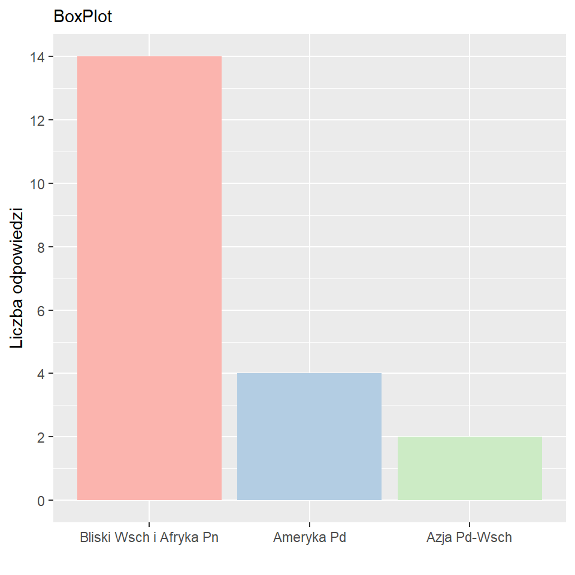

## Podsumowanie

Mamy problem z odczytywaniem danych na wykresach kołowych, kolory o mocnym kontraście zwracają naszą uwagę, a wykres BoxPlot nie jest taki straszny, jak się może wydawać. Pozwala również na przedstawienie większej ilości danych.